# Data Kategorik 1

ardi surya

2/11/2021

# Penggunaan Software R untuk Ekplorasi Data Kategorik

## Membaca Input data di R

```r
Data1 <- read.table("C:/Users/62816/Downloads/ADK/Data P8.txt", header=TRUE)
#membuat tabel kontingensi dari data
table1<-table(Data1$J.Kelamin,Data1$T.Pendidikan)
rowSums(table1)
```

```
##  0  1
##  9 41
```

```r
colSums(table1)
```

```
##  1  2  3  4
## 13 14  9 14
```

```r
#membuat tabel proporsi dari data
table2<-prop.table(table(Data1$J.Kelamin,Data1$T.Pendidikan))
table2
```

```
##
##        1    2    3    4
##   0 0.00 0.06 0.00 0.12
##   1 0.26 0.22 0.18 0.16
```

```r
#membuat tabel 3 dimensi atau lebih
table3<-ftable(Data1$J.Kelamin,Data1$T.Pendidikan,Data1$T.Pendapatan)
table3
```

```
##      1 2 3 4 5 6
##
## 0 1  0 0 0 0 0 0
##   2  0 1 1 0 1 0
##   3  0 0 0 0 0 0
##   4  1 0 3 1 1 0
## 1 1  2 1 1 2 3 4
##   2  0 1 4 4 2 0
##   3  1 2 3 1 1 1
##   4  2 1 0 2 2 1
```

### Deskripsi data menggunakan Grafik

Sajian grafis antar data kategorik yang dapat digunakan adalah: • The Grouped Dot Chart • The Grouped Dot-Whisker Chart • The Two-Way Dot Chart • The Side-by-Side Bar Chart • The Side-by-Side Bar-Whisker Chart • The Side-by-Side Stacked Bar Chart • The Mosaic Chart

Berikut ilustrasi penerapannya:

Suatu survei dilakukan terhadap pengguna dan bukan pengguna jasa-jasa keuangan. Berikut ini tersaji tabulasi silang antara pekerjaan responden dengan skor tingkat kemampuannya dalam pengelolaan keuangan. Bagaimanakah hubungan antar kedua peubah ini?

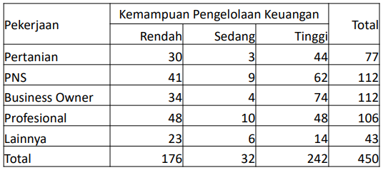

1. The Grouped Dot Chart

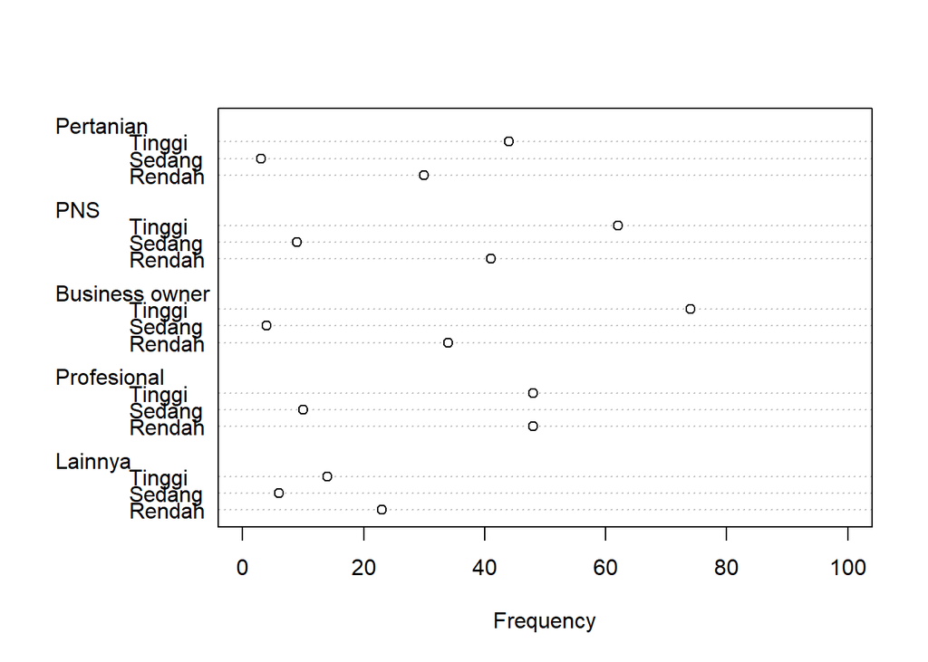

```r
#Program untuk pengelompokan berdasarkan pekerjaan
survei<-matrix(data=c(30,3,44,41,9,62,34,4,74,48,10,48,23,6,14),ncol=5,nrow=3,byrow=FALSE,dimnames=list(c("Rendah","Sedang","Tinggi"),c("Pertanian","PNS","Business owner","Profesional","Lainnya")))
dotchart(survei,xlab="Frequency",xlim=c(0,100))
```

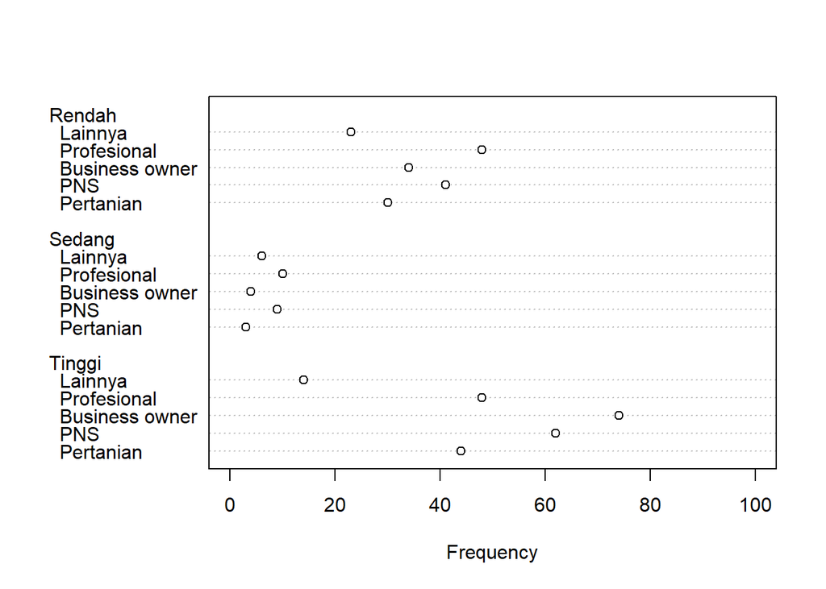

```r
#Program untuk pengelompokan berdasarkan kemampuan pengelolaan keuangan
dotchart(t(survei),xlab="Frequency",xlim=c(0,100))
```

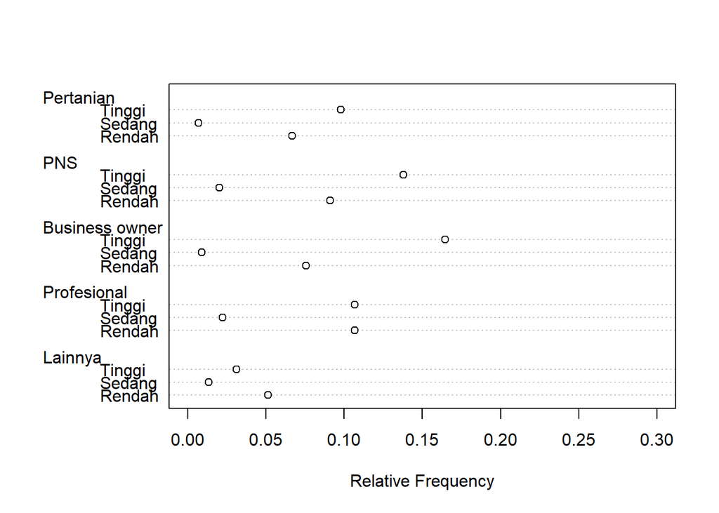

```r
#Bila diinginkan sajiannya berupa proporsi
n<-sum(survei)
propsurvei<-survei/n
dotchart(propsurvei,xlab="Relative Frequency", xlim=c(0,0.3))
```

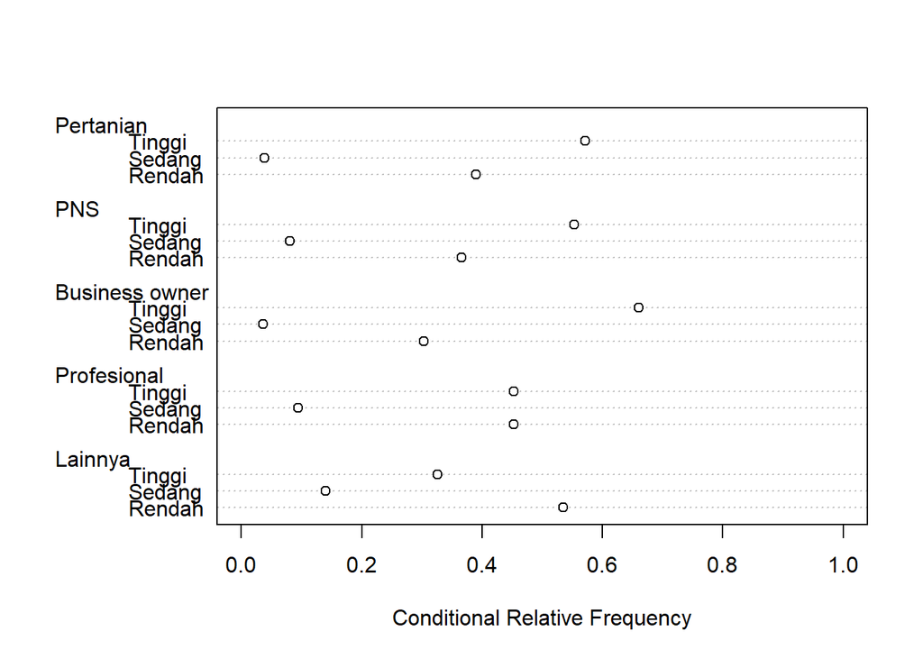

```r
#Proporsi dihitung menurut pekerjaan
jumkerja <- colSums(survei)
proppekerjaan <-survei/rbind(jumkerja,jumkerja,jumkerja)
dotchart(proppekerjaan,xlab="Conditional Relative Frequency",xlim=c(0,1))
```

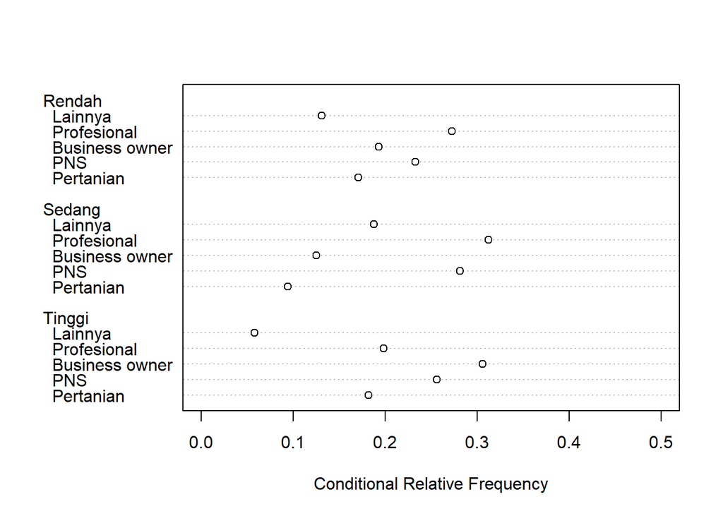

```r
#Proporsi dihitung menurut kemampuan perencanaan keuangan
jumrkeu <- rowSums(survei)
proprkeu <- t(survei)/rbind(jumrkeu,jumrkeu,jumrkeu,jumrkeu,jumrkeu)
dotchart(proprkeu,xlab="Conditional Relative Frequency",xlim=c(0,0.5))
```

2. The Grouped Dot-Whisker Chart Bila sajian grafik ditujukan untuk inferensia, statistik yang lebih tepat digunakan adalah proporsi yang didampingi dengan margin of error.

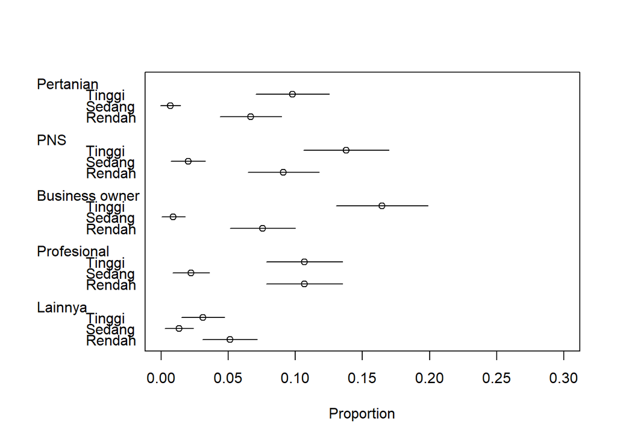

```r
survei<- matrix(data=c(30,3,44,41,9,62,34,4,74,48,10,48,23,6,14),ncol=5,nrow=3,byrow=FALSE,dimnames=list(c("Rendah","Sedang","Tinggi"),c("Pertanian","PNS","Business owner","Profesional","Lainnya")))
n<-sum(survei)
propsurvei<-survei/n
dotchart(propsurvei,xlab="Proportion",lcolor="white",xlim=c(0,0.3))
sd<-sqrt((1.-propsurvei)*propsurvei/n)
sd<-sd*qnorm(0.975)
hlo<-propsurvei-sd
hhi<-propsurvei+sd
titik<-c(propsurvei[,5],propsurvei[,4],propsurvei[,3],propsurvei[,2],propsurvei[,1])
kiri <-c(hlo[,5],hlo[,4],hlo[,3],hlo[,2],hlo[,1])
kanan<-c(hhi[,5],hhi[,4],hhi[,3],hhi[,2],hhi[,1])
dlx<-cbind(kiri,titik,kanan)
ys<-c(1:3,6:8,11:13,16:18,21:23)
dly<-cbind(ys,ys,ys)
ldl<-length(survei)
for (i in 1:ldl) lines(dlx[i,],dly[i,])
```

3. The Two-Way Dot Chart Alternatif sajian Dot Chart tidak secara tersarang, melainkan bersilang.

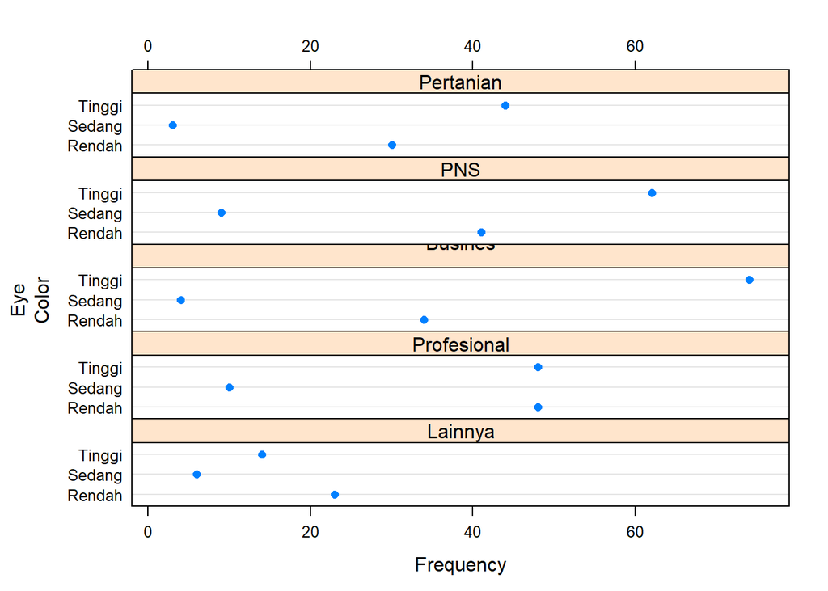

```r
survei<-
matrix(data=c(30,3,44,41,9,62,34,4,74,48,10,48,23,6,14),ncol=5,nrow=3,byrow=FALSE,dimnames=list(c("Rendah","Sedang","Tinggi"),c("Pertanian","PNS","Busines
s owner","Profesional","Lainnya")))
library(lattice)
dotplot(survei,xlab="Frequency",ylab="Eye
Color",as.table=TRUE,groups=FALSE,stack=FALSE,layout=c(1,5),scales=list(alternating=3))
```

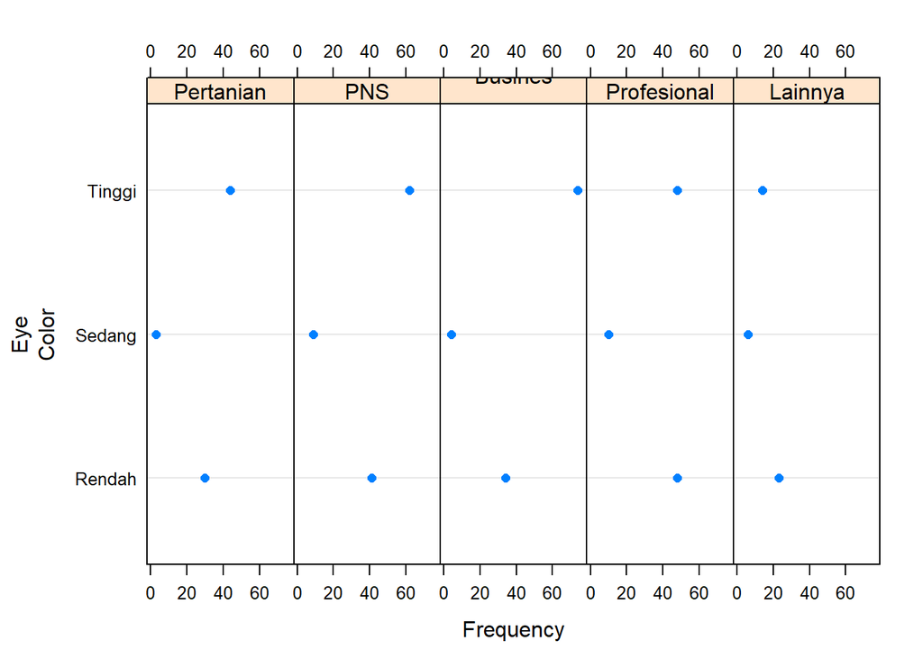

```r
dotplot(survei,xlab="Frequency",ylab="Eye
Color",as.table=TRUE,groups=FALSE,stack=FALSE,layout=c(5,1),scales=list(alternating=3))
```

4. The Side-by-Side Bar Chart

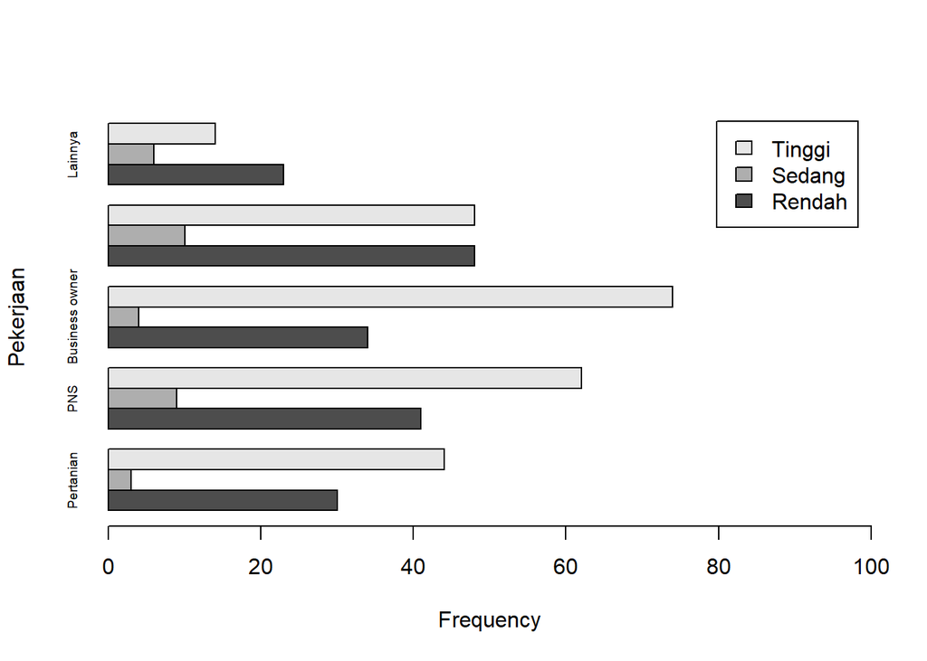

```r
#By Frequency
survei<-
matrix(data=c(30,3,44,41,9,62,34,4,74,48,10,48,23,6,14),ncol=5,nrow
=3,byrow=FALSE,dimnames=list(c("Rendah","Sedang","Tinggi"),c("Pertanian","PNS","Business owner","Profesional","Lainnya")))
barplot(survei,horiz=TRUE,xlab="Frequency",ylab="Pekerjaan",legend= rownames(survei),beside=TRUE,cex.names=0.6,xlim=c(0,100))
```

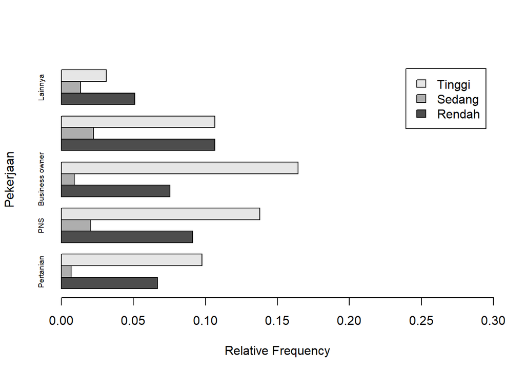

```r
#by Relative Frequency
n<-sum(survei)
propsurvei<-survei/n
barplot(propsurvei,horiz=TRUE,xlab="Relative Frequency",ylab="Pekerjaan",legend = rownames(propsurvei),beside=TRUE,cex.names=0.6,xlim=c(0,0.3))
```

4. The Side-by-Side Stacked Bar Chart

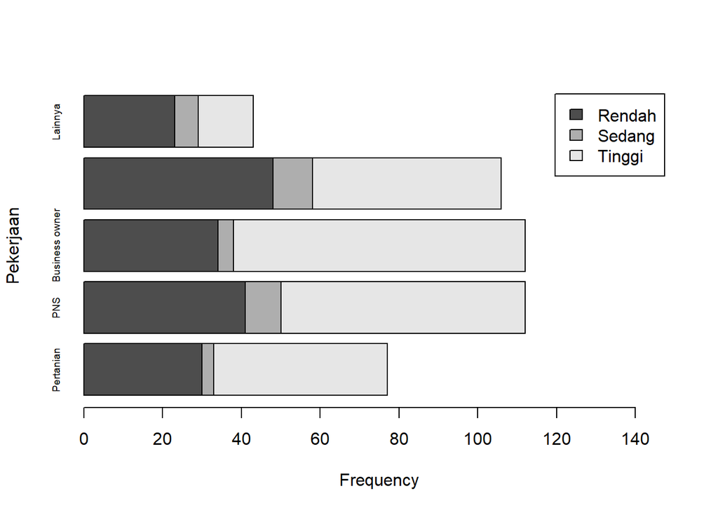

```r
survei<-matrix(data=c(30,3,44,41,9,62,34,4,74,48,10,48,23,6,14),ncol=5,nrow
=3,byrow=FALSE,dimnames=list(c("Rendah","Sedang","Tinggi"),c("Pertanian","PNS","Business owner","Profesional","Lainnya")))
barplot(survei,horiz=TRUE,xlab="Frequency",ylab="Pekerjaan",legend= rownames(survei),beside=FALSE,cex.names=0.6,xlim=c(0,150))
```

5. The Mosaic Chart

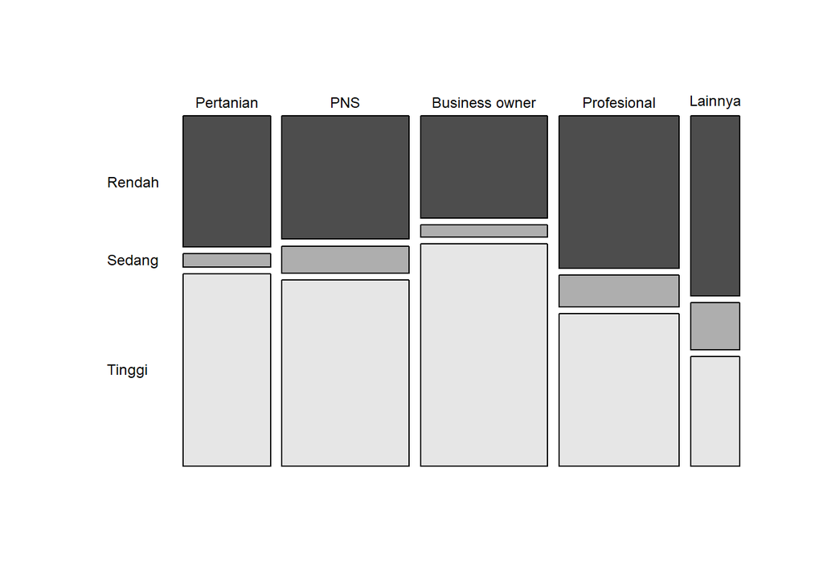

```r
survei<-
matrix(data=c(30,3,44,41,9,62,34,4,74,48,10,48,23,6,14),ncol=5,nrow=3,byrow=FALSE,dimnames=list(c("Rendah","Sedang","Tinggi"),c("Pertanian","PNS","Business owner","Profesional","Lainnya")))
mosaicplot(t(survei),main=" ", las=1,cex=0.75,color=TRUE)
```

## Peubah Acak

### Ilustrasi Sebaran Bernouli

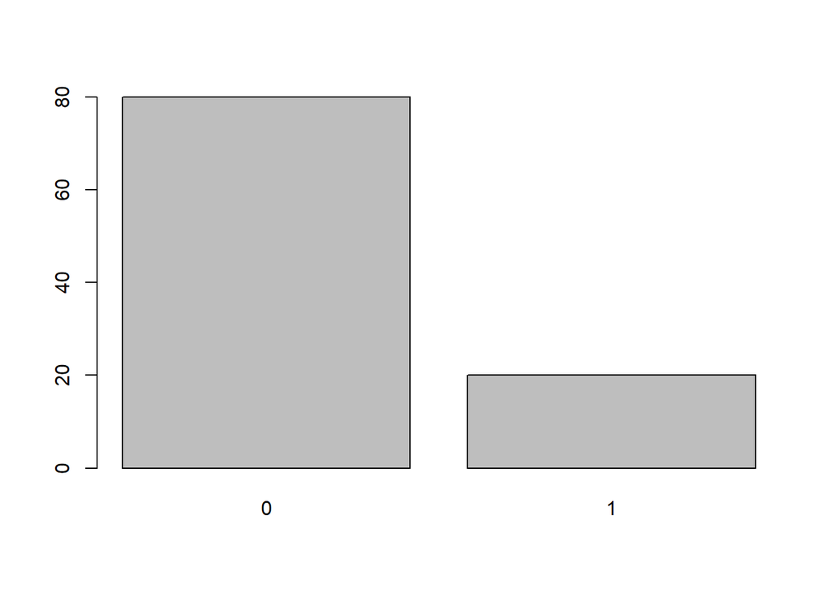

```r
x <- rbinom(100,1,0.2)
barplot(table(x))
```

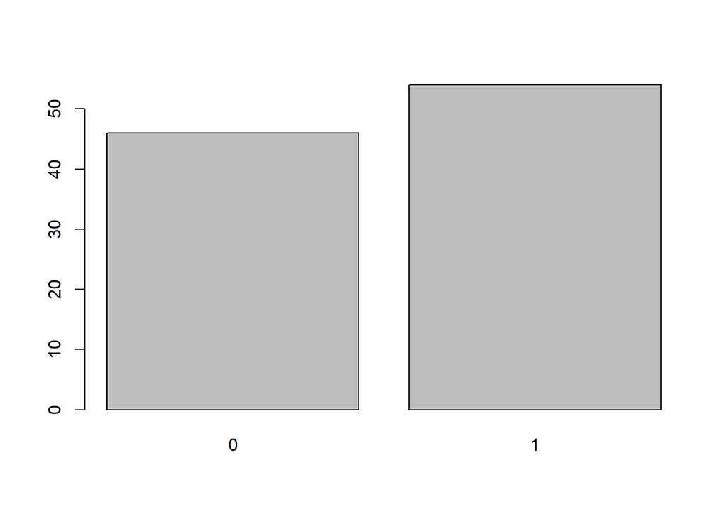

```r
y <- rbinom(100,1,0.5)
barplot(table(y))
```

### Ilustrasi Sebaran Binomial

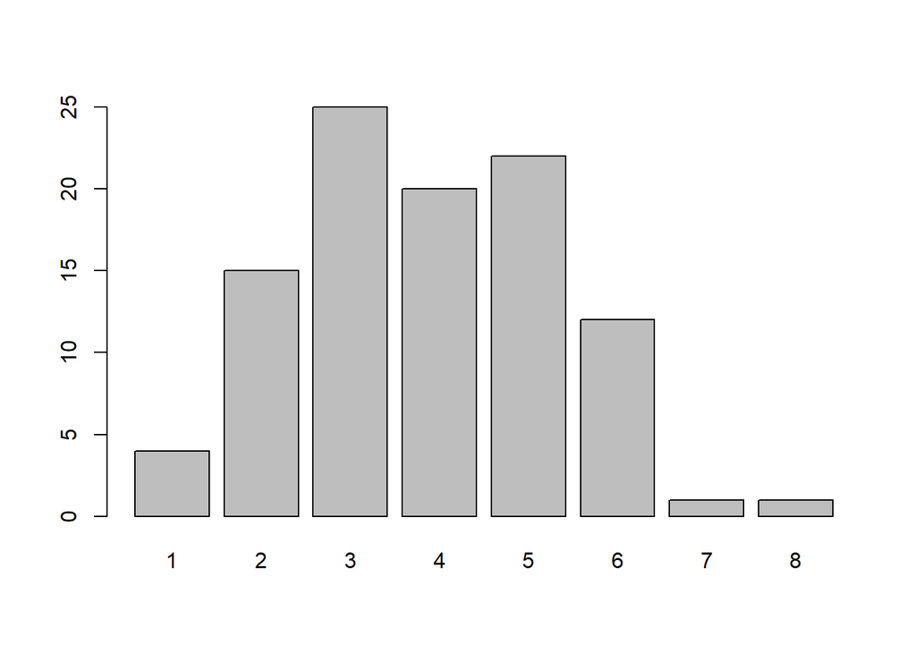

```r
#X~binom(8,0.5)
x <- rbinom(100,8,0.5)
barplot(table(x))
```

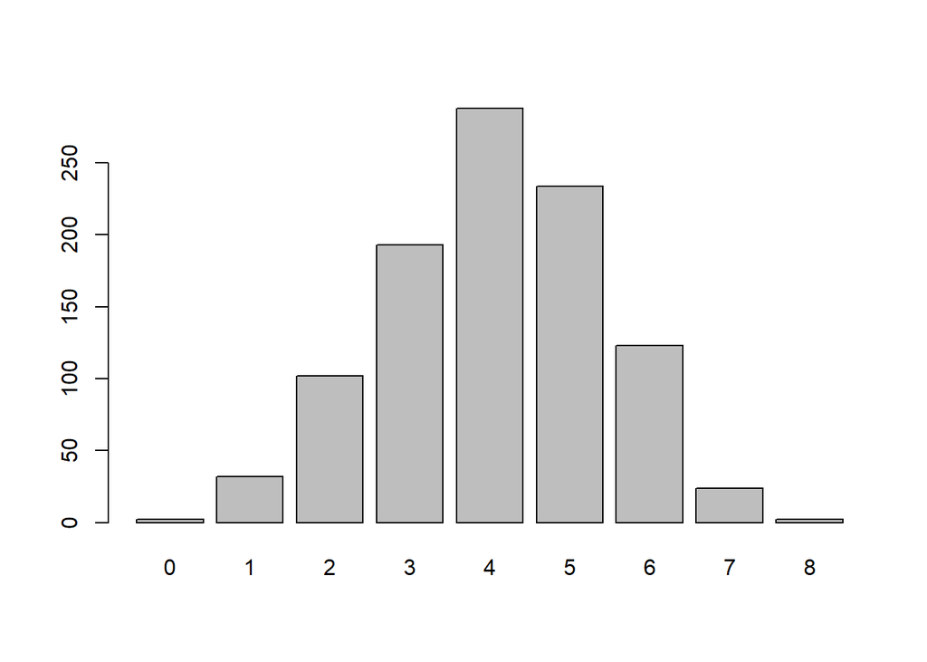

```r
#X~binom(8,0.5)
x <- rbinom(1000,8,0.5)
barplot(table(x))
```

**Contoh Soal Binomial:**

• Misalkan terdapat 12 nasabah asuransi di suatu tempat. Diketahui bahwa proporsi nasabah telat bayar polis ialah 1/6. Jika antar nasabah saling bebas, tentukanlah peluang bahwa terdapat 7 sampai 9 nasabah yang telat bayar polis! • X = banyaknya nasabah asuransi yang telat membayar • X ~ binomial(n = 12, p = 1/6) • P(7 ≤ X ≤ 9)

```r
pbinom(9, size=12, prob=1/6) - pbinom(6, size=12, prob=1/6)
```

```
## [1] 0.001291758
```

### Ilustrasi Sebaran Poisson

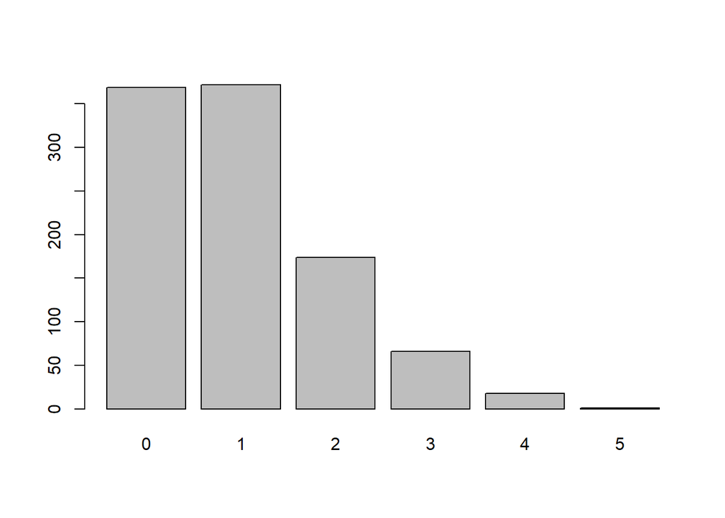

```r
#lamda = 1
x <- rpois(1000,1)
barplot(table(x))
```

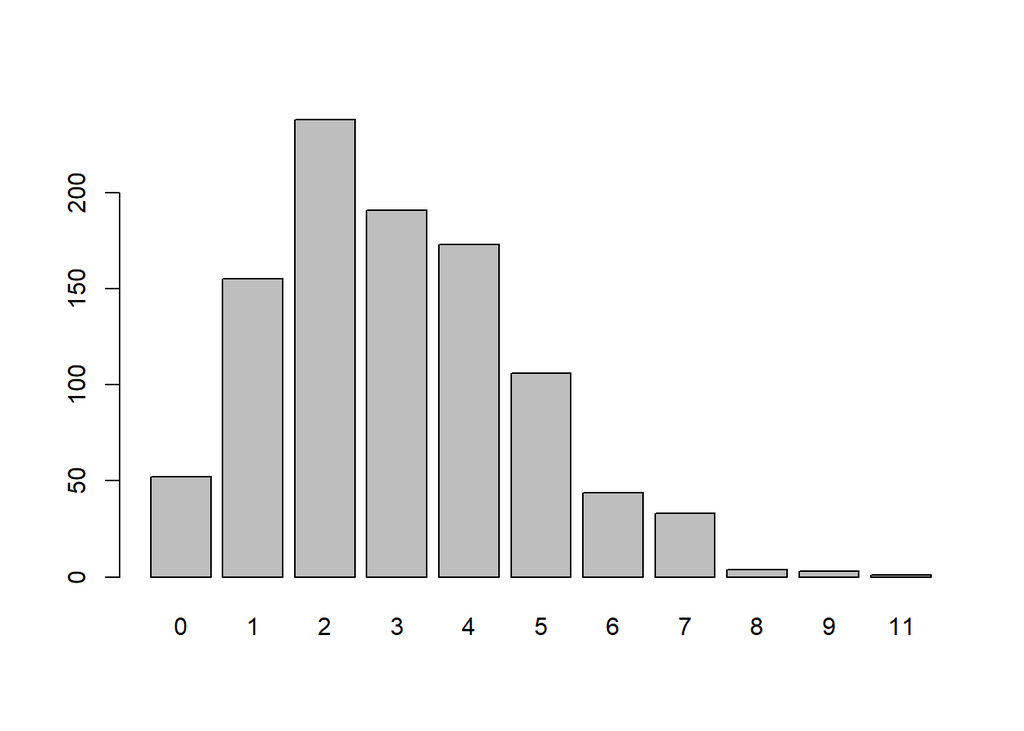

```r
#lamda = 3
x <- rpois(1000,3)
barplot(table(x))
```

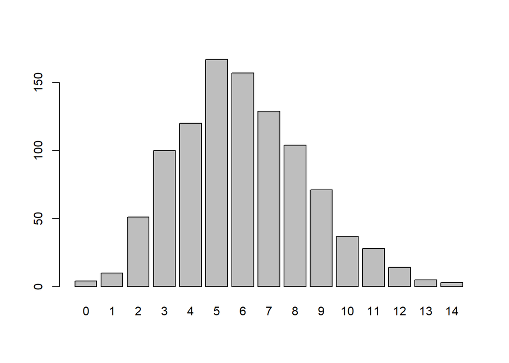

```r
#lamda = 6
x <- rpois(1000,6)
barplot(table(x))
```

**Contoh Soal Poisson:**

```r
#Misalkan: X= banyaknya mesin ATM rusak dalam waktu 1 tahun
#Maka X~poisson(lamda=1)
#a. P(X=0)
ppois(0, lambda = 1)
```

```
## [1] 0.3678794
```

```r
#b. Misalkan Y=banyaknya mesin ATM rusak dalam waktu 2 tahun maka Y~poisson(lamda=2)>>P(Y=2)
diff(ppois(c(1,2),lambda=2))
```

```
## [1] 0.2706706
```

### Ilustrasi Sebaran Geometrik

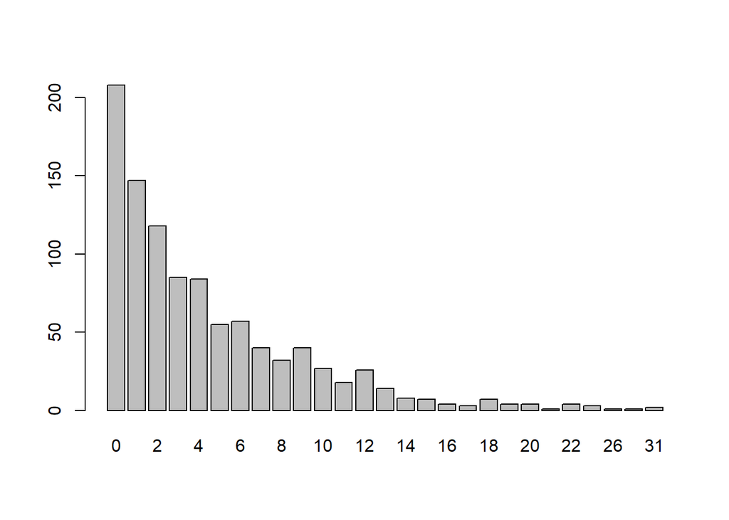

```r
x <- rgeom(1000,0.2)
barplot(table(x))
```

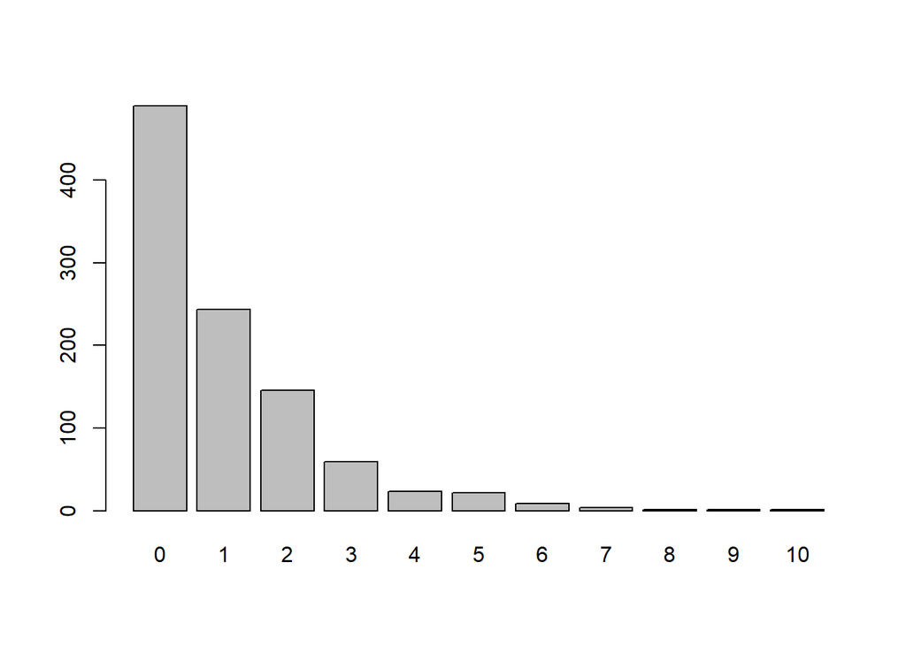

```r
x <- rgeom(1000,0.5)
barplot(table(x))
```

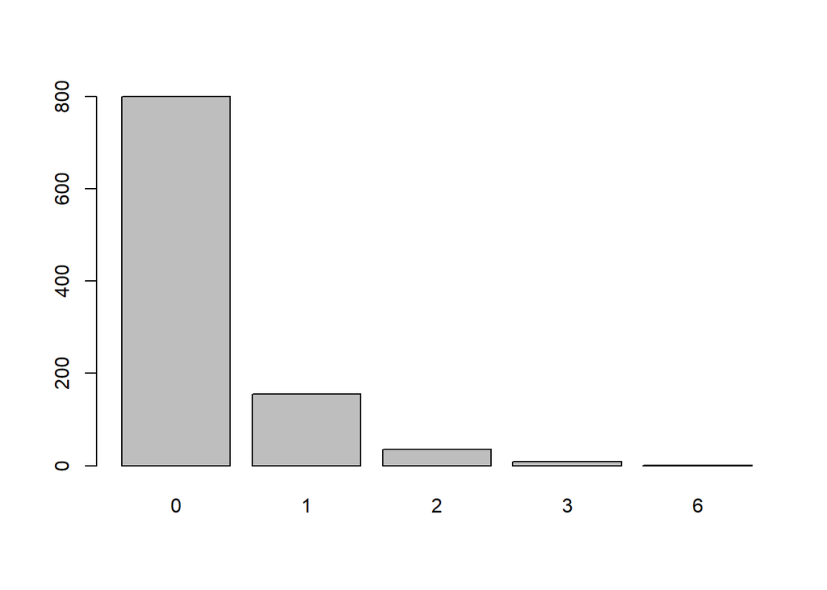

```r
x <- rgeom(1000,0.8)
barplot(table(x))
```

**Contoh Soal Geometrik:**

• Misalkan suatu bank melakukan pengambilan undian berhadiah untuk setiap bulan. Pak Yus adalah nasabah bank tersebut. Jika peluang keberhasilan Pak Yus memperoleh hadiah undian tersebut ialah 0.45. a. Berapakah peluang Pak Yus mendapatkan hadiah undian pada bulan ke-3 ? b. Berapakah peluang Pak Yus mendapatkan hadian undian minimal pada bulan ke-5 ?

```r
#Misalkan: X = banyaknya bulan yang dilalui sampai Pak Yus menang undian.
#Maka X~geometrik(p=0.45)
#a. P(X=3)
diff(pgeom(c(2,3),prob = 0.45))
```

```
## [1] 0.07486875
```

```r
#b. P(X>=5)=P(X>4)
pgeom(4,prob = 0.45,lower.tail = FALSE)
```

```
## [1] 0.05032844
```

### Ilustrasi Sebaran Hipergeometrik

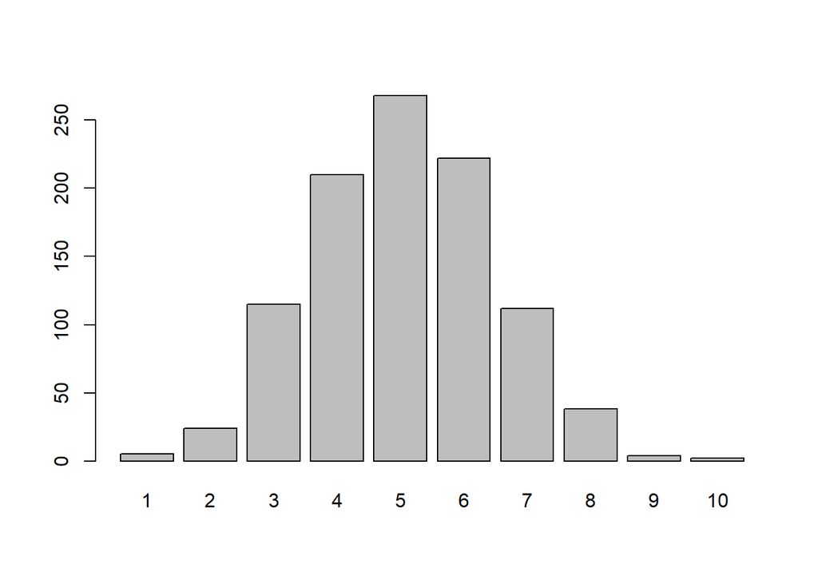

```r
x <- rhyper(1000,50,50,10)
barplot(table(x))
```

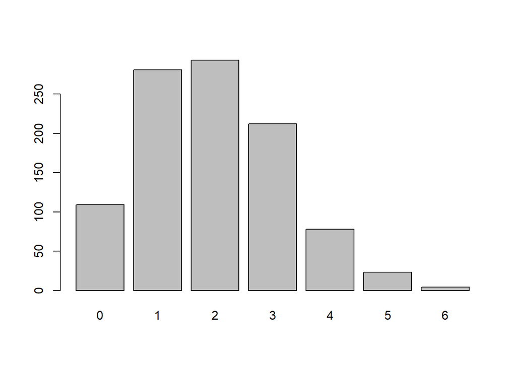

```r
x <- rhyper(1000,20,80,10)
barplot(table(x))
```

**Contoh Soal Hipergeometrik:**

• Misalkan terdapat 100 orang nasabah pada suatu bank dengan 2 kategori, yaitu kategori A dan B dengan masingmasing berisi 60 dan 40 orang nasabah. • Pada bank tersebut akan dilakukan pemilihan 20 nasabah secara acak untuk dijadikan responden suatu survei evaluasi. a. Berapakah peluang bahwa terpilih 10 orang nasabah kategori A dan 10 orang nasabah kategori B ?

```r
#Misalkan X = banyaknya nasabah kategori A yang terpilih
#Maka X~hipergeometrik(N=100, K=60, n=20)
#a. P(X=10)
dhyper(10, m=60, n=40, k=20)
```

```
## [1] 0.1192361
```

### Terima kasih

**Semoga materi ini bermanfaat**

**Ardi Surya**